# Project 2

Coco Donovan

2023-02-26

## Introduction:

For this project I chose three data sources to clean and perform analysis. The data sources are student test scores, presidential voting data, and different religions’ income break downs. All three data sets are examples of wide data and in this project I will attempt to make the data more usable analysis and then go on to conduct said analysis.

## Loading Necessary Packages

```r
library(tidyr)
library(dplyr)
library(readr)
library(reshape2)
```

```r
library(stringr)
library(ggplot2)
```

## Loading Data Source 1: Student Testing Data (Alice Ding)

```r
ds1_link <- 'https://gist.githubusercontent.com/Kimmirikwa/b69d0ea134820ea52f8481991ffae93e/raw/4db7b1698035ee29885d10e1a59bd902716ae168/student_results.csv'

ds1 <- read_csv(ds1_link)
```

## Cleaning Data Source 1

```r
ds1 <- ds1 %>%
  melt(id.vars = c('id', 'name', 'phone', 'sex and age','test number')) %>%
  rename(`term number` = variable, score = value)

ds1 <- ds1 %>%
  separate(`sex and age`, into = c("gender", "age"), sep = "_") %>%
  mutate(age = as.numeric(age))

knitr::kable(head(ds1))
```

| id | name | phone | gender | age | test number | term number | score |
| --- | --- | --- | --- | --- | --- | --- | --- |
| 1 | Mike | 134 | m | 12 | test 1 | term 1 | 76 |
| 2 | Linda | 270 | f | 13 | test 1 | term 1 | 88 |
| 3 | Sam | 210 | m | 11 | test 1 | term 1 | 78 |
| 4 | Esther | 617 | f | 12 | test 1 | term 1 | 68 |
| 5 | Mary | 114 | f | 14 | test 1 | term 1 | 65 |
| 1 | Mike | 134 | m | 12 | test 2 | term 1 | 85 |

## Converting ds1 to a csv

```r
write.csv(ds1, 'Students_Test_Scores.csv')
```

## The suggested analysis for Data Source One

The suggested analysis was, “We could find the average test score for each student or average test score overall. We could also count how many students are of each sex and find the average age as well.”

```r
# Average Test Score
avg_by_student <- ds1 %>%
  group_by(name) %>%
  summarise(avg_test_score = mean(score)) %>%
  arrange(desc(avg_test_score))

knitr::kable(avg_by_student)
```

| name | avg_test_score |
| --- | --- |
| Linda | 85.66667 |
| Mike | 83.66667 |
| Sam | 79.83333 |
| Esther | 73.33333 |
| Mary | 66.16667 |

```r
# Counts per gender
gender_counts <- unique(ds1[c("id", "gender")]) %>%
  group_by(gender) %>%
  summarize(count = n())

knitr::kable(gender_counts)
```

| gender | count |
| --- | --- |
| f | 3 |
| m | 2 |

```r
# Averages by gender
avg_by_gender <- ds1 %>%
  group_by(gender) %>%
  summarise(avg_test_score = mean(score)) %>%
  arrange(desc(avg_test_score))

knitr::kable(avg_by_gender)
```

| gender | avg_test_score |
| --- | --- |
| m | 81.75000 |
| f | 75.05556 |

## Loading Data Source 2: Religion and Income

I should note that I did not realize that RStudio has a built in table relig_income, but it had more religions than the example I originally provided, so I just recreated the example I provided for consistency.

```r
relig_inc <- read_csv('Raw_Religion_Income.csv')
```

## Cleaning Data Source 2

```r
relig_inc <- relig_inc %>%
  melt(id.vars = 'religion') %>%
  mutate(income_level = variable, count = value) %>%
  select(-variable, -value)

knitr::kable(head(relig_inc))
```

| religion | income_level | count |
| --- | --- | --- |
| Agnostic | <10k | 27 |
| Athiest | <10k | 12 |
| Buddhist | <10k | 27 |
| Catholic | <10k | 418 |
| refused | <10k | 15 |
| Agnostic | 10-20k | 34 |

## Writing relig_inc to a csv

```r
write.csv(relig_inc, "Religion_&_Income_Levels.csv")
```

## The suggested analysis for Data Source Two

The suggested analysis was, “As far as analysis goes you could group by religion and see what the religious makeup of all respondents was by percentages.”

```r
# Percent of respondents at each income level by religion

percents <- relig_inc %>%
  group_by(religion) %>%
  mutate(percent = round(100 * count/sum(count), 2)) %>%
  ungroup() %>%
  arrange(religion)

knitr::kable(head(percents))
```

| religion | income_level | count | percent |
| --- | --- | --- | --- |
| Agnostic | <10k | 27 | 3.27 |
| Agnostic | 10-20k | 34 | 4.12 |
| Agnostic | 20-30k | 60 | 7.26 |
| Agnostic | 30-40k | 81 | 9.81 |
| Agnostic | 40-50k | 76 | 9.20 |
| Agnostic | 50-75k | 137 | 16.59 |

## Loading Data Source 3:

```r
votes <- read_csv("presidential_vote_tallies.csv")
```

## Cleaning voter data and writing to a CSV

```r
votes <- votes %>%
  melt(id.vars = 'Candidate') %>%
  rename(State = variable, Number_of_votes = value)

knitr::kable(head(votes))
```

| Candidate | State | Number_of_votes |
| --- | --- | --- |
| Hillary Clinton | CA | 5931283 |
| Donald Trump | CA | 3184721 |
| Gary Johnson | CA | 308392 |
| Jill Stein | CA | 166311 |
| Hillary Clinton | FL | 4485745 |
| Donald Trump | FL | 4605515 |

```r
write.csv(votes,"vote_totals_by_state.csv")
```

## Analysis of voter data

The requested analysis was, “As per analysis, we can compare the vote counts in each state vs candidate.” So I decided to looks at the percentage results by state for each candidate.

```r
voting_percents <- votes %>%
  group_by(State) %>%
  mutate(percent = round(100 * Number_of_votes/sum(Number_of_votes), 2)) %>%
  ungroup() %>%
  select(-Number_of_votes)

knitr::kable(voting_percents)
```

| Candidate | State | percent |
| --- | --- | --- |
| Hillary Clinton | CA | 61.84 |
| Donald Trump | CA | 33.21 |
| Gary Johnson | CA | 3.22 |
| Jill Stein | CA | 1.73 |
| Hillary Clinton | FL | 47.92 |
| Donald Trump | FL | 49.20 |
| Gary Johnson | FL | 2.20 |
| Jill Stein | FL | 0.68 |

## Graphing voter data

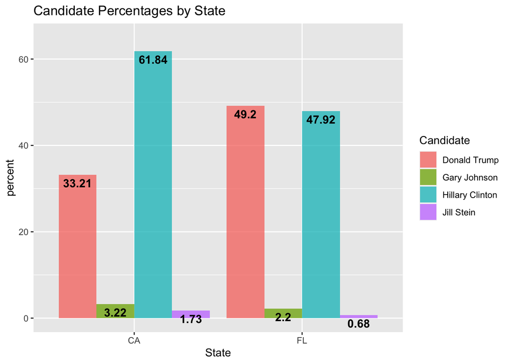

```r
ggplot(data = voting_percents, aes(x = State, y = percent, fill = Candidate)) +
  geom_bar(stat = "identity", position = position_dodge(), alpha = 0.75)  +
  ylim(0,65) +
  geom_text(aes(label = percent), fontface = "bold", vjust = 1.5,
             position = position_dodge(.9), size = 4) +
  labs(x = "State", title = "Candidate Percentages by State")
```

## Total Votes

I wanted to highlight the difference between popular opinion v.s. the electoral process.

```r
vote_totals <-votes %>%
  group_by(Candidate) %>%
  summarise(total_votes = sum(Number_of_votes)) %>%
  mutate(total_percents = round(100 * total_votes/sum(total_votes),2)) %>%
  select(-total_votes)

knitr::kable(head(vote_totals))
```

| Candidate | total_percents |
| --- | --- |
| Donald Trump | 41.11 |
| Gary Johnson | 2.71 |
| Hillary Clinton | 54.97 |
| Jill Stein | 1.22 |

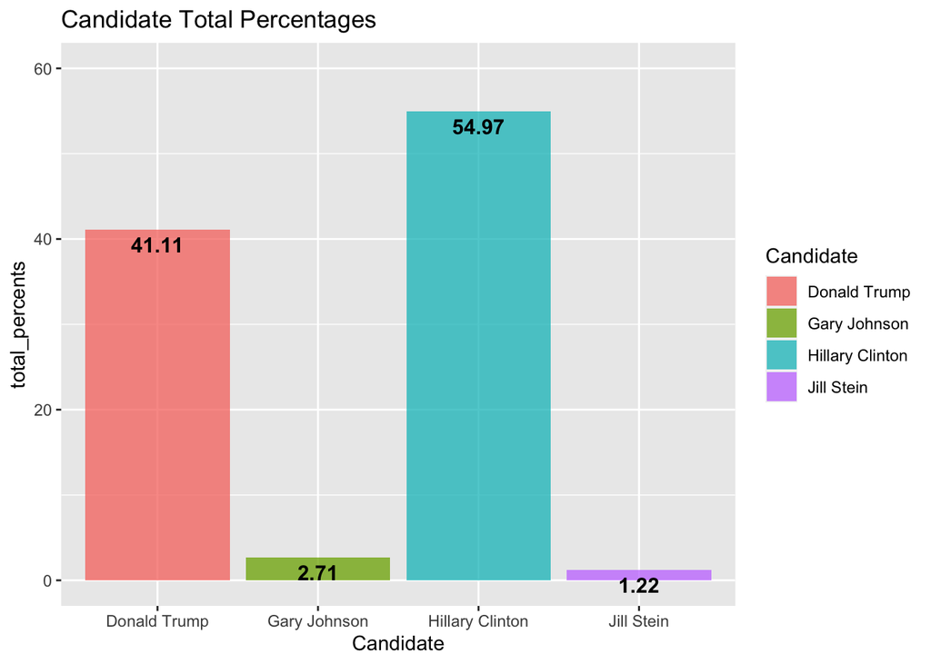

```r
ggplot(data = vote_totals, aes(x = Candidate, y = total_percents, fill = Candidate)) +
  geom_bar(stat = "identity", position = position_dodge(), alpha = 0.75)  +
  ylim(0,60) +
  geom_text(aes(label = total_percents), fontface = "bold", vjust = 1.5,
             position = position_dodge(.9), size = 4) +
  labs(x = "Candidate", title = "Candidate Total Percentages")
```

While this analysis only represents two states out of all fifty, it hopefully illustrates the disconnect between popular opinion and the president who may be elected. Trump did not win the popular vote, meaning a minority of American’s stated using a specific single choice voting method that they wanted Trump to be president and yet Trump won.

## Conclusion:

In this project I cleaned three data sources and performed analysis on each. I displayed students average grades by individual student and then by student gender. I went on to provide the percentage breakdowns of income by religion and concluded my project with an analysis of 2016 presidential election vote count from Florida and California. In my analysis, I found that tidyr, dplyr, and reshape2 were especially helpful packages. I had also used the function “melt” once before, and having used it in the past I relied heavily on it for the purpose of this project.